# Reference for data.table functionality

Nick Mader (nmader@chapinhall.org)

For several great example-based resources for seeing what data.table can do, see: - DataCamp’s data.table cheat sheet (saved under **H:references/data.table/data.table cheat sheet.pdf**) - the built-in function `example(data.table)` after loading the `data.table library` into `R`, and - Andrew Brooks’ great blog post on [Advanced Tips and Tricks with data.table](https://brooksandrew.github.io/simpleblog/articles/advanced-data-table/)

# Basics of `data.table`

We’ll start our demo with a simple data set that reflects as much richness as we’ll need. Later, we’ll generate much larger data sets to demonstrate the considerable speed advantages of data.table over data.frame methods.

Note that the data.frame “DF” and data.table “DT” have exactly parallel structure as displayed here. In R, their printed representations will differ slightly, where DT has a smarter printout, showing both head and tail rows, and field names printed at the bottom of the table for easier reference.

```r
library(data.table)
set.seed(60637)
DF <- data.frame(id     = 1:12,
                 prog   = rep(c("A", "B", "None"), each = 4),
                 sch    = rep(c("North", "South"), times = 6),
                 gender = sample(c("M", "F"), 12, replace = TRUE),
                 score  = runif(12))
DT <- data.table(DF, key = "id,prog,sch,gender")
DF
```

```
##    id prog   sch gender      score
## 1   1    A North      F 0.06739996
## 2   2    A South      F 0.92065630
## 3   3    A North      F 0.69107737
## 4   4    A South      F 0.04123674
## 5   5    B North      M 0.80921214
## 6   6    B South      M 0.10699104
## 7   7    B North      M 0.48964260
## 8   8    B South      M 0.05879476
## 9   9 None North      F 0.23495028
## 10 10 None South      M 0.36294500
## 11 11 None North      F 0.84634683
## 12 12 None South      M 0.88637177
```

```r
DT
```

```
##     id prog   sch gender      score
##  1:  1    A North      F 0.06739996
##  2:  2    A South      F 0.92065630
##  3:  3    A North      F 0.69107737
##  4:  4    A South      F 0.04123674
##  5:  5    B North      M 0.80921214
##  6:  6    B South      M 0.10699104
##  7:  7    B North      M 0.48964260
##  8:  8    B South      M 0.05879476
##  9:  9 None North      F 0.23495028
## 10: 10 None South      M 0.36294500
## 11: 11 None North      F 0.84634683
## 12: 12 None South      M 0.88637177
```

# General structure of working with `data.table` objects

Whereas data.frame contents can be accessed using square brackets and references to rows and columns, i.e. `df[*row indication*, *col indication*]`, data.table contents take three arguments: `dt[i,j,by]` where:

- i - indication of rows
- j - indication/operation on columns (optional)
- by - built-in ability to run operations with a subset

## Subsetting by rows

This works both by the familiar `dt[.]` with a comma demarcating rows vs. colums, or simply with `dt[]` with no comma.

```r
DT[3:5,]
```

```
##    id prog   sch gender      score
## 1:  3    A North      F 0.69107737
## 2:  4    A South      F 0.04123674
## 3:  5    B North      M 0.80921214
```

```r
DT[3:5]
```

```
##    id prog   sch gender      score
## 1:  3    A North      F 0.69107737
## 2:  4    A South      F 0.04123674
## 3:  5    B North      M 0.80921214
```

```r
DT[sch == "North"]
```

```
##    id prog   sch gender      score
## 1:  1    A North      F 0.06739996
## 2:  3    A North      F 0.69107737
## 3:  5    B North      M 0.80921214
## 4:  7    B North      M 0.48964260
## 5:  9 None North      F 0.23495028
## 6: 11 None North      F 0.84634683
```

```r
DT[prog %in% c("A", "B")]
```

```
##    id prog   sch gender      score
## 1:  1    A North      F 0.06739996
## 2:  2    A South      F 0.92065630
## 3:  3    A North      F 0.69107737
## 4:  4    A South      F 0.04123674
## 5:  5    B North      M 0.80921214
## 6:  6    B South      M 0.10699104
## 7:  7    B North      M 0.48964260
## 8:  8    B South      M 0.05879476
```

## Working with `data.table` columns

Referencing columns in data.table is also just a bit different than for data.frames. Rather than refering to column titles using their names, stored as a string, you refer to them using the unquoted name of the column. Think about this as similar to e.g. subset(), aggregate(), or within() functions, where you indicate the name of the data.frame and then are within the “environment” of that data.frame and can reference names of the columns directly, as if there were objects in the global environment.

```r
DT[, "sch"]
```

```
## [1] "sch"
```

```r
DT[1:5, sch]
```

```
## [1] North South North South North
## Levels: North South
```

However there are still two ways to reference columns by their string name.

The first is by using the get() function, whose (helpful!) job it it is to take the name of an object, stored as a string, and fetch you the object itself.

```r
DT[1:5, get("sch")]
```

```
## [1] North South North South North
## Levels: North South
```

The second is by using the `with=FALSE` option within the `data.table` object.

```r
DT[1:5, "sch", with = FALSE]
```

```
##      sch
## 1: North
## 2: South
## 3: North
## 4: South
## 5: North
```

```r
mycols <- c("prog", "sch")
DT[1:5, mycols, with = FALSE]
```

```
##    prog   sch
## 1:    A North
## 2:    A South
## 3:    A North
## 4:    A South
## 5:    B North
```

One way to think about why the name of the “with” argument makes sense is to think about the way that the `with()` function works. To recap that, by declaring a `data.frame` project in the first argument of a `with()` function, we can write a function in the second argument as if we were inside of that object. The formal way to think of this is that `with()` (and its related function `within()`) lets us operate inside of the “environment” of the `data.frame`.

For example:

```r
newDF <- data.frame(x = 1:10, y = 1:10 + rnorm(10))
cor(newDF[, "x"], newDF[, "y"])
```

```
## [1] 0.9585752
```

```r
with(newDF, cor(x,y))
```

```
## [1] 0.9585752
```

`data.table` naturally works as if it were its own `with()` (or `within()`) function where, as we saw above, we can use the names of the columns that exist within that `data.table` object’s environment without having to write out `DT$sch`, etc.

With all that in mind, the `with=FALSE` argument effectively turns off this functionality, allowing us to refer to column names using quoted strings (rather than their actual names) as is more familiar with `data.frame`s.

Additionally, think of groups of columns as lists:

```r
DT[1:3, list(id, sch)]
```

```
##    id   sch
## 1:  1 North
## 2:  2 South
## 3:  3 North
```

And note that “.()” is shorthand for “list()”

```r
DT[1:3, .(id, sch)]
```

```
##    id   sch
## 1:  1 North
## 2:  2 South
## 3:  3 North
```

Indeed, it may be interesting to know that data.frames are constructed as a special type of list, where each list element is of exactly the same length. The fact that lists can have contents of totally different types is what lets columns of data.frames have columns of different data types, unlike matrices which are also 2x2 tables but which can only have elements of the same (numeric) types.

For example, the following command loops through DF’s columns since, even though the `lapply` function receives the entire data frame as an argument, is knows to work with each of its columns separately since those are its base elements.

```r
class(DF)
```

```
## [1] "data.frame"
```

```r
typeof(DF)
```

```
## [1] "list"
```

```r
lapply(DF, function(x) class(x))
```

```
## $id
## [1] "integer"
##
## $prog
## [1] "factor"
##
## $sch
## [1] "factor"
##
## $gender
## [1] "factor"
##
## $score
## [1] "numeric"
```

### Creating new columns on the fly

`data.table` also allows for creation of new calculations of columns on the fly.

```r
DT[, mean(score)]
```

```
## [1] 0.4596354
```

```r
DT[, .(mean(score), sum(score))]
```

```
##           V1       V2
## 1: 0.4596354 5.515625
```

```r
DT[, .(mean_score = mean(score), sum_score = sum(score))]
```

```
##    mean_score sum_score
## 1:  0.4596354  5.515625
```

Note that `data.table` will “recycle” values as necessary to make sure that all output columns are of even length.

```r
DT[1:3, .(id, score, mean_score = mean(score))]
```

```
##    id      score mean_score
## 1:  1 0.06739996  0.5597112
## 2:  2 0.92065630  0.5597112
## 3:  3 0.69107737  0.5597112
```

### Using the `j`, or “columns” slot for creating output besides columns

The column, or `j`, argument can even take functions that do not return a column.

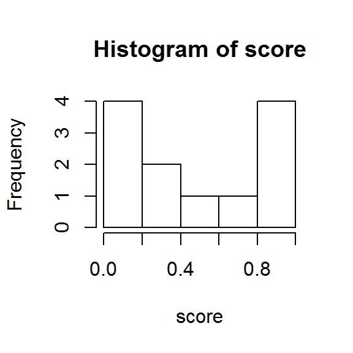

```r
DT[, hist(score)$histogram]
```

Note that we can use curly braces in `j` just as we do elsewhere in `R` to run multiple commands at once.

```
##  [1] 0.06739996 0.92065630 0.69107737 0.04123674 0.80921214 0.10699104
##  [7] 0.48964260 0.05879476 0.23495028 0.36294500 0.84634683 0.88637177
```

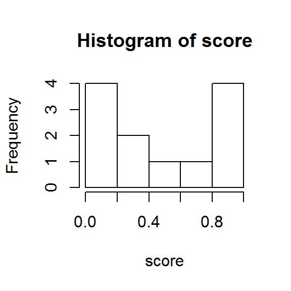

```r
DT[, {print(score)
      hist(score)$histogram
      }]
```

# Working with `by`s

`data.table` allows its operations to run on subsets of the data using a `by`.

The `by` argument can accept a character string…

```r
DT[, .(mean_score = mean(score)), by = "prog"]
```

```
##    prog mean_score
## 1:    A  0.4300926
## 2:    B  0.3661601
## 3: None  0.5826535
```

… or as a column object within the data.table object.

```r
DT[, .(mean_score = mean(score)), by = prog]
```

```
##    prog mean_score
## 1:    A  0.4300926
## 2:    B  0.3661601
## 3: None  0.5826535
```

We can do multiple “by”s with a string where the arguments are separated by commas although, interestingly, there cannot be spaces after the comma (at least in the current version.)

```r
#DT[, .(mean_score = mean(score)), by = "prog, sch"]
DT[, .(mean_score = mean(score)), by = "prog,sch"]
```

```
##    prog   sch mean_score
## 1:    A North  0.3792387
## 2:    A South  0.4809465
## 3:    B North  0.6494274
## 4:    B South  0.0828929
## 5: None North  0.5406486
## 6: None South  0.6246584
```

Other ways of doing multiple “by”s include using list syntax (i.e. the “.()”)…

```r
DT[, .(mean_score = mean(score)), by = .(prog,sch)]
```

```
##    prog   sch mean_score
## 1:    A North  0.3792387
## 2:    A South  0.4809465
## 3:    B North  0.6494274
## 4:    B South  0.0828929
## 5: None North  0.5406486
## 6: None South  0.6246584
```

… or with a vector of character names for the intended columns.

```r
myBys <- c("prog", "sch")
DT[, .(mean_score = mean(score)), by = myBys]
```

```
##    prog   sch mean_score
## 1:    A North  0.3792387
## 2:    A South  0.4809465
## 3:    B North  0.6494274
## 4:    B South  0.0828929
## 5: None North  0.5406486
## 6: None South  0.6246584
```

Just like with columns, we can generate “by” information on the fly

```r
DT[, .(mean_score = mean(score)), by = .(inAnyProg = prog %in% c("A", "B"))]
```

```
##    inAnyProg mean_score
## 1:      TRUE  0.3981264
## 2:     FALSE  0.5826535
```

And note that we can put all of our tricks together–use of the `i` argument for subsetting, `j` argument for calling and running calculations on columns, and `by` argument for subsetting–resulting in a very quick and elegant (and *fast*, as we will see below) operation.

```r
DT[sch == "North", .(mean_score = mean(score)), by = "gender"]
```

```
##    gender mean_score
## 1:      F  0.4599436
## 2:      M  0.6494274
```

# Working with special values

These values include `.N`, `.I`, `.GRP`, `.SD` and others, which have special meaning inside of a `data.table` object.

```r
DT[, .(count = .N, index = .I, groupnum = .GRP), by = prog]
```

```
##     prog count index groupnum
##  1:    A     4     1        1
##  2:    A     4     2        1
##  3:    A     4     3        1
##  4:    A     4     4        1
##  5:    B     4     5        2
##  6:    B     4     6        2
##  7:    B     4     7        2
##  8:    B     4     8        2
##  9: None     4     9        3
## 10: None     4    10        3
## 11: None     4    11        3
## 12: None     4    12        3
```

## Using `.SD` to perform operations across many columns

`.SD` is shorthand for all of the columns besides those used in the “by”.

```r
n <- 100
scores <- data.frame(cat = sample(LETTERS[1:3], n, replace = TRUE),
                     score1 = runif(n),
                     score2 = rnorm(n),
                     score3 = rlogis(n))
dtScores <- data.table(scores)
dtScores[,lapply(.SD, mean), by = "cat"]
```

```
##    cat    score1      score2     score3
## 1:   C 0.4633326  0.05235810  0.5299358
## 2:   A 0.4850643 -0.06751854  0.3010502
## 3:   B 0.5858445  0.14131708 -0.1096519
```

Subsets of all of the columns can be determined by adding a argument of `.SDcols` to the `data.table` object.

```r
dtScores[,lapply(.SD, mean), by = "cat", .SDcols = c("score2","score3")]
```

```
##    cat      score2     score3
## 1:   C  0.05235810  0.5299358
## 2:   A -0.06751854  0.3010502
## 3:   B  0.14131708 -0.1096519
```

It is even possible to combine multiple types of calculations at once, including mixtures of using .SD and field names directly. To do so, use a `c()` function across all of the field output represented as list objects.

```r
dtScores[,c(.(newCatName = paste("Category", cat)),
            lapply(.SD, mean)),
            by = "cat", .SDcols = c("score2","score3")]
```

```
##    cat newCatName      score2     score3
## 1:   C Category C  0.05235810  0.5299358
## 2:   A Category A -0.06751854  0.3010502
## 3:   B Category B  0.14131708 -0.1096519
```

### Generating calculations across columns

Although `lapply(.SD, FUN)` allows for sequential operations of function `FUN` on columns, it does not allow for calculations *across* columns. For example, if we interesting in the maximum score across *rows*, the following code only obtains the max within *columns*.

```r
scoreCols <- c("score1", "score2","score3")
dtScores[, lapply(.SD, max), .SDcols = scoreCols]
```

```
##     score1   score2   score3
## 1: 0.99738 2.764689 4.956339
```

An `apply()` function can obtain the right result.

```r
max_apply <- apply(dtScores[, scoreCols, with = FALSE], 1, max)
head(max_apply)
```

```
## [1] 1.3626815 0.5344791 0.6160612 0.9897169 0.3383548 0.5194556
```

```r
class(max_apply)
```

```
## [1] "numeric"
```

But another approach within the `data.table` environment is using `do.call`, which runs a function on `.SD` as a full list of arguments. In the below example, note that `pmax()` is a “parallel” max, meaning that it operates row-by-row, similar to `rowMeans()`.

```r
max_do.call <- dtScores[, .(do.call(what = pmax, args = .SD)), .SDcols = scoreCols]
head(max_do.call)
```

```
##           V1
## 1: 1.3626815
## 2: 0.5344791
## 3: 0.6160612
## 4: 0.9897169
## 5: 0.3383548
## 6: 0.5194556
```

```r
class(max_do.call)
```

```
## [1] "data.table" "data.frame"
```

The advantage of implementing these calculations using `data.table` is that they can be combine with other column calculations, subsetting, and `by`s.

# Using the `:=` operator for assigning new columns

Using `:=` generates an assignment within the data table. Rather than being an on-the-fly calculation which returns compressed information for just that calculation, `:=` directly modifies the underlying data.

Contrast the two commands below, where the former returns a reduced output, and the latter extend the data set.

```r
DT[, .(mean_score  = mean(score)), by = prog]
```

```
##    prog mean_score
## 1:    A  0.4300926
## 2:    B  0.3661601
## 3: None  0.5826535
```

```r
DT[,   mean_score := mean(score),  by = prog]
DT
```

```
##     id prog   sch gender      score mean_score
##  1:  1    A North      F 0.06739996  0.4300926
##  2:  2    A South      F 0.92065630  0.4300926
##  3:  3    A North      F 0.69107737  0.4300926
##  4:  4    A South      F 0.04123674  0.4300926
##  5:  5    B North      M 0.80921214  0.3661601
##  6:  6    B South      M 0.10699104  0.3661601
##  7:  7    B North      M 0.48964260  0.3661601
##  8:  8    B South      M 0.05879476  0.3661601
##  9:  9 None North      F 0.23495028  0.5826535
## 10: 10 None South      M 0.36294500  0.5826535
## 11: 11 None North      F 0.84634683  0.5826535
## 12: 12 None South      M 0.88637177  0.5826535
```

Note that, in this case, it would be redundant to assign the output to a new object, i.e. don’t do: `newDT <- DT[, mean_score := mean(score), by = prog]`.

The `:=` operator can be used to create multiple new columns.

```r
DT[, c("A", "B") := .(runif(nrow(DT)), letters[1:nrow(DT)])]
DT
```

```
##     id prog   sch gender      score mean_score          A B
##  1:  1    A North      F 0.06739996  0.4300926 0.99472494 a
##  2:  2    A South      F 0.92065630  0.4300926 0.53539385 b
##  3:  3    A North      F 0.69107737  0.4300926 0.16518716 c
##  4:  4    A South      F 0.04123674  0.4300926 0.38879808 d
##  5:  5    B North      M 0.80921214  0.3661601 0.95150068 e
##  6:  6    B South      M 0.10699104  0.3661601 0.64901708 f
##  7:  7    B North      M 0.48964260  0.3661601 0.66792134 g
##  8:  8    B South      M 0.05879476  0.3661601 0.45006602 h
##  9:  9 None North      F 0.23495028  0.5826535 0.09316608 i
## 10: 10 None South      M 0.36294500  0.5826535 0.83533529 j
## 11: 11 None North      F 0.84634683  0.5826535 0.01814163 k
## 12: 12 None South      M 0.88637177  0.5826535 0.79070859 l
```

Columns can be removed by using `:=` to assign columns to `NULL`.

```r
DT[, "mean_score" := NULL]
DT[, c("A", "B") := NULL]
DT
```

```
##     id prog   sch gender      score
##  1:  1    A North      F 0.06739996
##  2:  2    A South      F 0.92065630
##  3:  3    A North      F 0.69107737
##  4:  4    A South      F 0.04123674
##  5:  5    B North      M 0.80921214
##  6:  6    B South      M 0.10699104
##  7:  7    B North      M 0.48964260
##  8:  8    B South      M 0.05879476
##  9:  9 None North      F 0.23495028
## 10: 10 None South      M 0.36294500
## 11: 11 None North      F 0.84634683
## 12: 12 None South      M 0.88637177
```

The below code check demonstrates the use of `:=` in a more applied example, together with `.SD`, to show how we can easily perform many operations to create or update columns in our data set.

```r
scoreCols <- paste0("score", 1:3)
scoreCols
```

```
## [1] "score1" "score2" "score3"
```

```r
dtScores[, paste0(scoreCols, "_std"):=lapply(.SD, scale), .SDcols = scoreCols]
head(dtScores)
```

```
##    cat    score1     score2     score3    score1_std score2_std
## 1:   C 0.4107338 -0.2059243  1.3626815 -0.4146887050 -0.2399282
## 2:   A 0.5332221  0.5344791  0.2629012  0.0528753891  0.4780464
## 3:   B 0.3370365 -0.2056456  0.6160612 -0.6960071022 -0.2396579
## 4:   B 0.9897169 -0.2612257 -1.1541002  1.7954134835 -0.2935543
## 5:   A 0.3383548 -0.2935531  0.2236364 -0.6909748131 -0.3249024
## 6:   C 0.5194556  0.3287739 -3.0585323  0.0003258152  0.2785726
##     score3_std
## 1:  0.70042136
## 2:  0.04156486
## 3:  0.25313597
## 4: -0.80733247
## 5:  0.01804210
## 6: -1.94823976
```

```r
dtScores[, lapply(.SD, mean), .SDcols = paste0(scoreCols, "_std")]
```

```
##      score1_std   score2_std    score3_std
## 1: 1.874813e-16 -1.20585e-17 -3.761097e-18
```

# Chaining

Chaining is a straightforward way to perform multiple sequential operations on a given object, where the operations occur from left to right.

The idea of chaining is not unique to `data.table` objects, but can be very handy.

```r
# A fully spelled-out sequential process
temp <- DT[, score_mean := mean(score), by = prog]
temp[score_mean>0.4]
```

```
##    id prog   sch gender      score score_mean
## 1:  1    A North      F 0.06739996  0.4300926
## 2:  2    A South      F 0.92065630  0.4300926
## 3:  3    A North      F 0.69107737  0.4300926
## 4:  4    A South      F 0.04123674  0.4300926
## 5:  9 None North      F 0.23495028  0.5826535
## 6: 10 None South      M 0.36294500  0.5826535
## 7: 11 None North      F 0.84634683  0.5826535
## 8: 12 None South      M 0.88637177  0.5826535
```

```r
# Done by chaining
DT[, score_mean := mean(score), by = prog][score_mean>0.4]
```

```
##    id prog   sch gender      score score_mean
## 1:  1    A North      F 0.06739996  0.4300926
## 2:  2    A South      F 0.92065630  0.4300926
## 3:  3    A North      F 0.69107737  0.4300926
## 4:  4    A South      F 0.04123674  0.4300926
## 5:  9 None North      F 0.23495028  0.5826535
## 6: 10 None South      M 0.36294500  0.5826535
## 7: 11 None North      F 0.84634683  0.5826535
## 8: 12 None South      M 0.88637177  0.5826535
```

## Curly braces

Another way to perform many operations at once within a single `data.table` statement is using curly braces, where only the last statement is returned.

```r
DT[, {
  gender_long <- ifelse(gender == "F", "Female", "Male")
  score_0to100 <- round(score * 100, 0)
  .(id = id, prog = prog, gender = gender_long, score = score_0to100)
     }]
```

```
##     id prog gender score
##  1:  1    A Female     7
##  2:  2    A Female    92
##  3:  3    A Female    69
##  4:  4    A Female     4
##  5:  5    B   Male    81
##  6:  6    B   Male    11
##  7:  7    B   Male    49
##  8:  8    B   Male     6
##  9:  9 None Female    23
## 10: 10 None   Male    36
## 11: 11 None Female    85
## 12: 12 None   Male    89
```

# Using `data.table` for data manipulations

Note that a `data.table` object also “inherits” from `data.frame` object properties.

```r
class(DT)
```

```
## [1] "data.table" "data.frame"
```

That means that operations that you commonly perform on `data.frame`s will work with `data.table` objects too (although some things may vary). Some examples:

```r
DT$plusfive <- DT$score + 5
DT <- within(DT, {
    someProg <- ifelse(prog == "None", "Nope", "Yep")
    fSomeProg <- factor(someProg)
})
subset(DT, id >= 6)
```

```
##    id prog   sch gender      score score_mean plusfive fSomeProg someProg
## 1:  6    B South      M 0.10699104  0.3661601 5.106991       Yep      Yep
## 2:  7    B North      M 0.48964260  0.3661601 5.489643       Yep      Yep
## 3:  8    B South      M 0.05879476  0.3661601 5.058795       Yep      Yep
## 4:  9 None North      F 0.23495028  0.5826535 5.234950      Nope     Nope
## 5: 10 None South      M 0.36294500  0.5826535 5.362945      Nope     Nope
## 6: 11 None North      F 0.84634683  0.5826535 5.846347      Nope     Nope
## 7: 12 None South      M 0.88637177  0.5826535 5.886372      Nope     Nope
```

```r
str(DT)
```

```
## Classes 'data.table' and 'data.frame':   12 obs. of  9 variables:
##  $ id        : int  1 2 3 4 5 6 7 8 9 10 ...
##  $ prog      : Factor w/ 3 levels "A","B","None": 1 1 1 1 2 2 2 2 3 3 ...
##  $ sch       : Factor w/ 2 levels "North","South": 1 2 1 2 1 2 1 2 1 2 ...
##  $ gender    : Factor w/ 2 levels "F","M": 1 1 1 1 2 2 2 2 1 2 ...
##  $ score     : num  0.0674 0.9207 0.6911 0.0412 0.8092 ...
##  $ score_mean: num  0.43 0.43 0.43 0.43 0.366 ...
##  $ plusfive  : num  5.07 5.92 5.69 5.04 5.81 ...
##  $ fSomeProg : Factor w/ 2 levels "Nope","Yep": 2 2 2 2 2 2 2 2 1 1 ...
##  $ someProg  : chr  "Yep" "Yep" "Yep" "Yep" ...
##  - attr(*, ".internal.selfref")=<externalptr>
##  - attr(*, "index")= int
##  - attr(*, "sorted")= chr  "id" "prog" "sch" "gender"
```

However, there are some things that don’t work as expected.

```r
DT <- within(DT, {
    male <- FALSE
    male[gender == "M"] <- TRUE
})
cbind(DT, DT$gender == "M")
```

```
##     id prog   sch gender      score score_mean plusfive fSomeProg someProg
##  1:  1    A North      F 0.06739996  0.4300926 5.067400       Yep      Yep
##  2:  2    A South      F 0.92065630  0.4300926 5.920656       Yep      Yep
##  3:  3    A North      F 0.69107737  0.4300926 5.691077       Yep      Yep
##  4:  4    A South      F 0.04123674  0.4300926 5.041237       Yep      Yep
##  5:  5    B North      M 0.80921214  0.3661601 5.809212       Yep      Yep
##  6:  6    B South      M 0.10699104  0.3661601 5.106991       Yep      Yep
##  7:  7    B North      M 0.48964260  0.3661601 5.489643       Yep      Yep
##  8:  8    B South      M 0.05879476  0.3661601 5.058795       Yep      Yep
##  9:  9 None North      F 0.23495028  0.5826535 5.234950      Nope     Nope
## 10: 10 None South      M 0.36294500  0.5826535 5.362945      Nope     Nope
## 11: 11 None North      F 0.84634683  0.5826535 5.846347      Nope     Nope
## 12: 12 None South      M 0.88637177  0.5826535 5.886372      Nope     Nope
##      male    V2
##  1: FALSE FALSE
##  2:    NA FALSE
##  3:    NA FALSE
##  4:    NA FALSE
##  5:  TRUE  TRUE
##  6:  TRUE  TRUE
##  7:  TRUE  TRUE
##  8:  TRUE  TRUE
##  9:    NA FALSE
## 10:  TRUE  TRUE
## 11:    NA FALSE
## 12:  TRUE  TRUE
```

But there are alternatives:

```r
DT$male <- FALSE
DT[gender == "M", male := TRUE] # NSM: Not understanding/thrilled by auto print when data.table does these manipulations
DT[, .(gender, male)]
```

```
##     gender  male
##  1:      F FALSE
##  2:      F FALSE
##  3:      F FALSE
##  4:      F FALSE
##  5:      M  TRUE
##  6:      M  TRUE
##  7:      M  TRUE
##  8:      M  TRUE
##  9:      F FALSE
## 10:      M  TRUE
## 11:      F FALSE
## 12:      M  TRUE
```

## Merging

(Under construction.)

# Saving time with `data.table`

## Assigning values

Depending on the nature of variable assignment or reassignment, `data.table` can have incredibly significant advantages. Taking an example from - Andrew Brooks’ [blog post](https://brooksandrew.github.io/simpleblog/articles/advanced-data-table/) mentioned above, here is a case of having an extremely large table, where we try to reassign a large number of values in certain points within a data set.

```r
M = matrix(1, nrow=100000, ncol=100)
DF = as.data.frame(M)
DT = as.data.table(M)
system.time(for (i in 1:1000) DF[i, 1L] <- i)
```

```
##    user  system elapsed
##    0.25    0.36    0.63
```

```r
system.time(for (i in 1:1000) DT[i, V1:=i])
```

```
##    user  system elapsed
##     0.4     0.0     0.4
```

```r
system.time(for (i in 1:1000) M[i, 1L] <- i)
```

```
##    user  system elapsed
##    0.00    0.03    0.03
```

```r
system.time(for (i in 1:1000) set(DT, i, 1L, i))
```

```
##    user  system elapsed
##       0       0       0
```

The conclusion here is that use of methods specialized to `data.table` (here, the `set` function) can lead to significant speed-ups, even equivalent to better optimized data structures like matrices. See the `data.table` documentation or e-mail me (address is above) with questions about other potential uses of these specialized functions.

## Calculations with `by`s

First, we will generate a large data set to simulate common situations of data use.

```r
n <- 1e7
dfBig <- data.frame(cat = sample(LETTERS[1:4], n, replace = TRUE), x = rnorm(n))
dtBig <- data.table(dfBig)
dtBigKey <- data.table(dfBig, key = "cat")
```

Here, contrasting several methods–`aggregate()` which is available in base `R`, `ddply` from the popular `plyr` package written by Hadley Wickham, and two methods using `data.table` methods.

```r
library(plyr)
system.time(mean_agg <- aggregate(x ~ cat, data = dfBig, mean))
```

```
##    user  system elapsed
##    9.27    0.75   10.12
```

```r
system.time(mean_ply <- ddply(dfBig, .(cat), summarize, x_mean = mean(x)))
```

```
##    user  system elapsed
##    0.70    0.28    0.99
```

```r
system.time(mean_dt  <- dtBig[, mean(x), by = "cat"])
```

```
##    user  system elapsed
##    0.15    0.00    0.15
```

```r
system.time(mean_key <- dtBigKey[, mean(x), by = "cat"])
```

```
##    user  system elapsed
##    0.12    0.00    0.12
```

One takeaways are that `data.table` operations are orders of magnitude faster than common methods, and can be several times faster than even other popular packages in `R`. Another is that some of `data.table`s advantages do not even require a key to have been set to generate rapid calculations.

Below, we inspecting the results to confirm that they are equivalent. Note: we use the `magrittr` package to “pipe” the results of one function into the first argument of another

```r
library(magrittr)
merge(mean_agg, mean_ply, by = "cat") %>% merge(mean_dt, by = "cat") %>% merge(mean_key, by = "cat")
```

```
##   cat             x        x_mean          V1.x          V1.y
## 1   A  1.341542e-03  1.341542e-03  1.341542e-03  1.341542e-03
## 2   B  5.339101e-05  5.339101e-05  5.339101e-05  5.339101e-05
## 3   C  3.591310e-04  3.591310e-04  3.591310e-04  3.591310e-04
## 4   D -5.823982e-04 -5.823982e-04 -5.823982e-04 -5.823982e-04
```